# HW3_93111185

Parnian kassraie - 93111185

October 17, 2016

```r
#Adding Libraries:

library(readr)
library(dplyr)
library(tidyr)
library(coin)
library(magrittr)
library(ggplot2)
library(highcharter)

#Loading Data:

load("data/asg.rda")
load("data/bsg.rda")
load("data/ash.rda")
load("data/atg.rda")
load("data/bts.rda")
load("data/btm.rda")
load("data/ast.rda")
load("data/bst.rda")
load("data/acg.rda")
load("data/bcg.rda")
```

## 1. Students lose interest in learning maths during years of education:

### 1.1 Data:

The Data relevant to this question can be found in *asg.rda* and *bsg.rda* which is the students background qestionnaire data. Variables I’m going to work with are listed below:

- IDCNTRY : Student’s Country
- IDSTUD : Student’s Unique ID Within Country
- IDPOP : Student’s School Grade (4th & 8th)
- ITSEX : Student’s Gender
- ABSM01A/SQBSBM14A : Enjoy Learning Maths
- ABSM01B/SQBSBM14B : Wish Have Not To Study Math
- ABSM01D/SQBSBM14D : Learn Interesting Stuff

```r
#Extracting the data
smi = rbind(select(asg,idcntry,idstud,idpop,itsex,q1=asbm01a,q2=asbm01b,q3=asbm01d),
            select(bsg,idcntry,idstud,idpop,itsex,q1=bsbm14a,q2=bsbm14b,q3=bsbm14d))

smi %>% filter(!is.na(q1),!is.na(q2),!is.na(q3))->smi
smi$q1=abs(smi$q1-4)
smi$q2=abs(smi$q2-4)
smi$q3=abs(smi$q3-4)
```

### 1.2 Plotting:

In the following plots the distribution of each of these 3 variables is plotted.

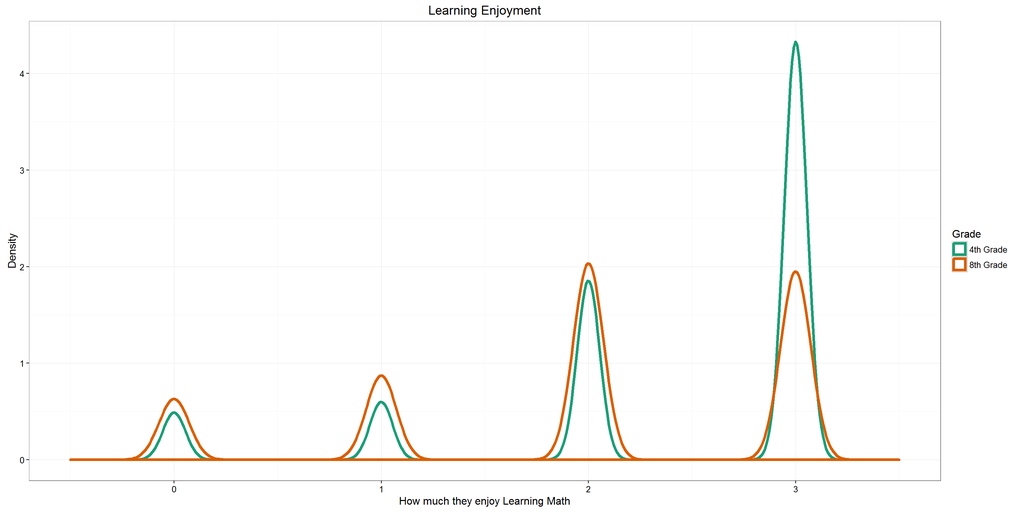

```r
#Enjoy Learning
ggplot(smi,aes(q1,color=factor(idpop)))+geom_density(size=rel(1.5))+
  scale_color_brewer(palette = "Dark2",name="Grade",labels=c("4th Grade","8th Grade"))+
  labs(x="How much they enjoy Learning Math",y="Density",title="Learning Enjoyment")+xlim(-.5,3.5)+
  theme_bw()
```

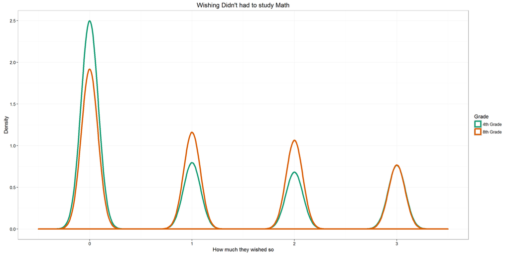

```r
#wish didn't have to study math
ggplot(smi,aes(q2,color=factor(idpop)))+geom_density(size=rel(1.5))+
  scale_color_brewer(palette = "Dark2",name="Grade",labels=c("4th Grade","8th Grade"))+
  labs(x="How much they wished so",y="Density",title="Wishing Didn't had to study Math")+xlim(-.5,3.5)+
  theme_bw()
```

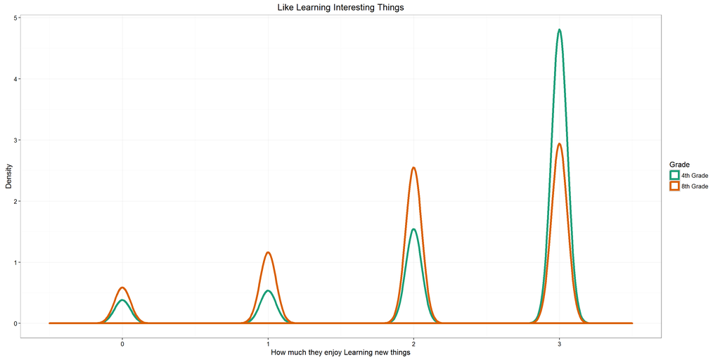

```r
#learn interesting stuff
ggplot(smi,aes(q3,color=factor(idpop)))+geom_density(size=rel(1.5))+
  scale_color_brewer(palette = "Dark2",name="Grade",labels=c("4th Grade","8th Grade"))+
  labs(x="How much they enjoy Learning new things",y="Density",title="Like Learning Interesting Things")+xlim(-.5,3.5)+
  theme_bw()
```

A certain difference can be seen in the distributions. We’ll make it more quantitive in the following section.

### 1.3 Numeric Calculations:

We’ll calculate the quantiles of our samples to gain some sense over them.

```r
quantile(filter(smi,idpop==1)$q1)
```

```
##   0%  25%  50%  75% 100%
##    0    2    3    3    3
```

```r
quantile(filter(smi,idpop==2)$q1)
```

```
##   0%  25%  50%  75% 100%
##    0    1    2    3    3
```

```r
quantile(filter(smi,idpop==1)$q2)
```

```
##   0%  25%  50%  75% 100%
##    0    0    0    2    3
```

```r
quantile(filter(smi,idpop==2)$q2)
```

```
##   0%  25%  50%  75% 100%
##    0    0    1    2    3
```

```r
quantile(filter(smi,idpop==1)$q3)
```

```
##   0%  25%  50%  75% 100%
##    0    2    3    3    3
```

```r
quantile(filter(smi,idpop==2)$q3)
```

```
##   0%  25%  50%  75% 100%
##    0    2    2    3    3
```

### 1.4 Hypothesis Testing:

Enjoyment Variable is an ordinal variable, meaning that it’s value doens’t mean anything and only the rank matters. Thus, it is better tested using the wilcoxon rank sum test. I’ll compare the Results of the 3 questions/variables above for 4th and 8th grade.

```r
#Enjoy Learning
wilcox.test(filter(smi,idpop==1)$q1,filter(smi,idpop==2)$q1,alternative="greater")
```

```
##
##  Wilcoxon rank sum test with continuity correction
##
## data:  filter(smi, idpop == 1)$q1 and filter(smi, idpop == 2)$q1
## W = 4.8372e+10, p-value < 2.2e-16
## alternative hypothesis: true location shift is greater than 0
```

```r
#wish didn't have to study math
wilcox.test(filter(smi,idpop==1)$q2,filter(smi,idpop==2)$q2,alternative="less")
```

```
##
##  Wilcoxon rank sum test with continuity correction
##
## data:  filter(smi, idpop == 1)$q2 and filter(smi, idpop == 2)$q2
## W = 3.4198e+10, p-value < 2.2e-16
## alternative hypothesis: true location shift is less than 0
```

```r
#learn interesting stuff
wilcox.test(filter(smi,idpop==1)$q3,filter(smi,idpop==2)$q3,alternative="greater")
```

```
##
##  Wilcoxon rank sum test with continuity correction
##
## data:  filter(smi, idpop == 1)$q3 and filter(smi, idpop == 2)$q3
## W = 4.8658e+10, p-value < 2.2e-16
## alternative hypothesis: true location shift is greater than 0
```

### 1.5 Analyzing the results:

The Results of the tests are stated below:

| Hypothesis Subject | P-value | True Location Shift of H1 compared to H2 |
| --- | --- | --- |
| Enjoy Learning Maths | $2.2e-16$ | Greater |
| Wish They Didn’t Had to Study Math | $2.2e-16$ | Less |
| Enjoy Learning Interesting Stuff | $2.2e-16$ | Greater |

In each of the test above, the first Hypothesis is that the distributions aren’t the same between 4th and 8th graden, and the second hypothesis opposes this. According to the table we can see that the fondness distributions are certainly not the same. * 4th graders enjoy learning math more than 8th graders. * 8th grader wished they didn’t have to study math more than 4th graders. * 4th graders enjoy learning interesintg suff more than 8th graders.

## 2.Iranian students are better at reasoning than at applying.

### 2.1 Data:

The data relevant to this question can be found both in *asa.rda* and *asg.rda*, we’ll choose *asg.rda* and *bsg.rda* again.The following variables are going to be used:

- ASMAPP01-ASMAPP05/BSMAPP01-BSMAPP05 : Math applying Scores
- ASMREA01-ASMREA05/BSMREA01-BSMREA05 : Math Reasoning Scores
- ASSAPP01-ASSAPP05/BSSAPP01-BSSAPP05 : Science applying Scores
- ASSREA01-ASSREA05/BSSREA01-BSSREA05 : Science Reasoning Scores
- IDCNTRY : Student’s Country
- IDSTUD : Student’s Unique ID Within Country
- IDGRADE : Student’s School Grade
- ITSEX : Student’s Gender

There are 5 distinct plausible values for students scores in math/science reasoning/applying, so there are 20 score columns relevant to our question. Since we’re not aware of the calculation methodology of these values, I’m just going to use they’re average as the student’s score.

```r
asg %>% mutate(ma=round((asmapp01+asmapp02+asmapp03+asmapp04+asmapp05)/5,2),
               mr=round((asmrea01+asmrea02+asmrea03+asmrea04+asmrea05)/5,2),
               sa=round((assapp01+assapp02+assapp03+assapp04+assapp05)/5,2),
               sr=round((assrea01+assrea02+assrea03+assrea04+assrea05)/5,2))->asg

bsg %>% mutate(ma=round((bsmapp01+bsmapp02+bsmapp03+bsmapp04+bsmapp05)/5,2),
               mr=round((bsmrea01+bsmrea02+bsmrea03+bsmrea04+bsmrea05)/5,2),
               sa=round((bssapp01+bssapp02+bssapp03+bssapp04+bssapp05)/5,2),
               sr=round((bssrea01+bssrea02+bssrea03+bssrea04+bssrea05)/5,2))->bsg


rba=rbind(select(asg,idcntry,idstud,idgrade,itsex,ma,mr,sa,sr),
          select(bsg,idcntry,idstud,idgrade,itsex,ma,mr,sa,sr))

rba %>% filter(idcntry==364)->rba
```

### 2.2 Plotting:

In the Plot below the score distribution of each of this sclaes (reasoning and applying) is compared. The red line indicates the *Reasoning score distribtion* and the blue line is the *Applying Score distribution*. Also, The green and yellow lines represent *Science Reasoning* and *Science Applying* respectively. They Seem Slightly different. Later will find out if this difference is meaningful.

```r
highchart() %>%
  hc_add_series_density(density(rba$mr),name = "Math Reasoning Distribution") %>%
  hc_add_series_density(density(rba$ma),name = "Math Applying Distribution") %>%
  hc_add_series_density(density(rba$sr),name = "Science Reasoning Distribution") %>%
  hc_add_series_density(density(rba$sa),name = "Science Applying Distribution") %>%
  hc_title(text = "Various Score Distributions ") %>%
  hc_add_theme(hc_theme_smpl())
```

[interactive chart not shown]

### 2.3 Numeric Calculations:

We’ll calculate the quantiles of our samples to gain some sense over them.

```r
quantile(rba$ma)
```

```
##     0%    25%    50%    75%   100%
##  73.55 356.72 420.06 485.92 736.61
```

```r
quantile(rba$mr)
```

```
##     0%    25%    50%    75%   100%
## 116.77 367.29 427.39 487.88 756.36
```

```r
quantile(rba$sa)
```

```
##     0%    25%    50%    75%   100%
## 163.52 405.57 467.47 525.72 803.66
```

```r
quantile(rba$sr)
```

```
##     0%    25%    50%    75%   100%
##  59.51 411.22 475.28 535.86 778.92
```

```r
quantile((rba$ma+rba$sa)/2)
```

```
##      0%     25%     50%     75%    100%
## 118.535 385.365 443.475 501.230 761.815
```

```r
quantile((rba$mr+rba$sr)/2)
```

```
##      0%     25%     50%     75%    100%
##  91.850 392.555 450.900 508.220 748.650
```

### 2.4 Hypothesis Testing:

I’ll be using the t-test here, since the variables are continues (scores of the students in reasoning and applying) and due to the large number of samples, taking advantage of the central limit theorem, we can assume that the sample mean distribution is normal. Now we want to see if the sample mean distribution of *Reasoning Score* and *Applying Score* are the same or not. first I’ll take the t-test on science and math separatly and eventually I’ll take an average on math/science to derive a general reasoning score.

```r
# Mathematical Reasoning/Applying t-test:
t.test(rba$ma,rba$mr)
```

```
##
##  Welch Two Sample t-test
##
## data:  rba$ma and rba$mr
## t = -5.1598, df = 23522, p-value = 2.492e-07
## alternative hypothesis: true difference in means is not equal to 0
## 95 percent confidence interval:
##  -8.360050 -3.757112
## sample estimates:
## mean of x mean of y
##  423.3896  429.4482
```

```r
#Scientific Reasoning/Applying t-test:
t.test(rba$sa,rba$sr)
```

```
##
##  Welch Two Sample t-test
##
## data:  rba$sa and rba$sr
## t = -5.6415, df = 23526, p-value = 1.705e-08
## alternative hypothesis: true difference in means is not equal to 0
## 95 percent confidence interval:
##  -8.948026 -4.333533
## sample estimates:
## mean of x mean of y
##  465.2592  471.9000
```

```r
#General Reasoning.Applying t-test:
t.test((rba$ma+rba$sa)/2,(rba$mr+rba$sr)/2)
```

```
##
##  Welch Two Sample t-test
##
## data:  (rba$ma + rba$sa)/2 and (rba$mr + rba$sr)/2
## t = -5.7507, df = 23576, p-value = 8.999e-09
## alternative hypothesis: true difference in means is not equal to 0
## 95 percent confidence interval:
##  -8.513916 -4.185444
## sample estimates:
## mean of x mean of y
##  444.3244  450.6741
```

[output not shown]

## 3. Children of the more educated parents are more successful at school.

### 3.1 Data:

In this part, we have to merge the following columns from *ash* and *asg* dataframes. since we only have the *Home Background* Data for the 4th graders, this question will not include the 8th graders.

*IDCNTRY : Student’s Country* IDSTUD : Student’s ID Within Country *ASDHEDUP : Parent’s Highest Education Level* ASMMAT01-ASMMAT05 : Student’s Overall Math Score Plausible Values *ASSSCI01-ASSSCI05 : Student’s Overall Science Score Plausible Values

The Educational Level Variable Takes The following Values:

| Value | Meaning |
| --- | --- |
| 1 | UniverSity or Higher |
| 2 | Post Secondary But not University |
| 3 | Upper Secondary |
| 4 | Lower Secondary |
| 5 | Some Primary, Lower Secondary or No School |
| 6 | Not Applicable |

```r
ash %>% select(asdhedup,idcntry,idstud) -> ashe
asg %>% mutate(ms=round((asmmat01+asmmat02+asmmat03+asmmat04+asmmat05)/5,2),
               ss=round((asssci01+asssci02+asssci03+asssci04+asssci05)/5,2)) %>%
                 select(idcntry,idstud,ms,ss)->asge

spe <- merge(ashe,asge,by=c("idcntry","idstud"))
spe %>% filter(!is.na(asdhedup)) %>% filter(asdhedup<6)->spe
remove(ashe)
remove(asge)
```

### 3.2 Plotting:

We will compare the boxplots of score distribution for each level of parent’s education to gain some sense about the data.

```r
highchart() %>%
  hc_add_series_boxplot(spe$ms,by=spe$asdhedup,name="Science Score") %>%
  hc_add_series_boxplot(spe$ss,by=spe$asdhedup,name="Math Score") %>%
  hc_add_theme(hc_theme_google()) %>%
  hc_yAxis(title = list(text = "Score Distribution")) %>%
  hc_xAxis(title = list(text = "Parents Education Level")) %>%
  hc_title(text = "success vs. Parents Education")
```

[interactive chart not shown]

We can vividly see that the average score drops are the education level decreases. Let’s find out if this drop shows some correlation between these variables.

### 3.3 Numeric Calculations:

We’ll calculate the quantiles of our samples to gain some sense over them.

```r
l1<-filter(spe,asdhedup==1)
l2<-filter(spe,asdhedup==2)
l3<-filter(spe,asdhedup==3)
l4<-filter(spe,asdhedup==4)
l5<-filter(spe,asdhedup==5)

quantile((l1$ss+l1$ms)/2)
```

```
##      0%     25%     50%     75%    100%
## 118.380 468.990 532.615 584.620 803.660
```

```r
quantile((l2$ss+l2$ms)/2)
```

```
##       0%      25%      50%      75%     100%
## 119.9150 457.8138 515.6950 564.7075 773.0950
```

```r
quantile((l3$ss+l3$ms)/2)
```

```
##      0%     25%     50%     75%    100%
##  88.160 432.835 496.785 549.115 817.095
```

```r
quantile((l4$ss+l4$ms)/2)
```

```
##      0%     25%     50%     75%    100%
##  78.510 376.360 455.315 517.830 772.955
```

```r
quantile((l4$ss+l4$ms)/2)
```

```
##      0%     25%     50%     75%    100%
##  78.510 376.360 455.315 517.830 772.955
```

```r
quantile((l5$ss+l5$ms)/2)
```

```
##      0%     25%     50%     75%    100%
##  93.420 302.885 391.360 468.755 721.275
```

### 3.4 Hypothesis Testing:

The objective is to find out whether there is a relation between parents’ education and student success (in which we meassure by their overall scores in math and science). The score is a continues variable and since we have a great number of samples, we can use the central limit theorem and assume that the average score has a normal distribution. Therefore, I’ll be using the t-test here. Since we have 5 levels of education, we’ll take couple of different t-test to find out how exactly the parents education effects the child’s success.

```r
#t-test between university level education and highschool level (1 & 2)

t.test((l1$ss+l1$ms)/2,(l2$ss+l2$ms)/2)
```

```
##
##  Welch Two Sample t-test
##
## data:  (l1$ss + l1$ms)/2 and (l2$ss + l2$ms)/2
## t = 22.491, df = 65850, p-value < 2.2e-16
## alternative hypothesis: true difference in means is not equal to 0
## 95 percent confidence interval:
##  13.02785 15.51526
## sample estimates:
## mean of x mean of y
##  520.8206  506.5490
```

```r
#t-test between upper and lower secondry (3 & 4)
t.test((l3$ss+l3$ms)/2,(l4$ss+l4$ms)/2)
```

```
##
##  Welch Two Sample t-test
##
## data:  (l3$ss + l3$ms)/2 and (l4$ss + l4$ms)/2
## t = 48.502, df = 33112, p-value < 2.2e-16
## alternative hypothesis: true difference in means is not equal to 0
## 95 percent confidence interval:
##  40.46042 43.86823
## sample estimates:
## mean of x mean of y
##  484.2494  442.0851
```

```r
#t-test between lower secondry and primary/no school (4 & 5)
t.test((l4$ss+l4$ms)/2,(l5$ss+l5$ms)/2)
```

```
##
##  Welch Two Sample t-test
##
## data:  (l4$ss + l4$ms)/2 and (l5$ss + l5$ms)/2
## t = 45.14, df = 27308, p-value < 2.2e-16
## alternative hypothesis: true difference in means is not equal to 0
## 95 percent confidence interval:
##  52.87541 57.67571
## sample estimates:
## mean of x mean of y
##  442.0851  386.8095
```

```r
#t-test between
remove(l1)
remove(l2)
remove(l3)
remove(l4)
remove(l5)
```

### 3.5 Analyzing the results:

| Data Vectors | P-value | Mean of Higher Level | Mean of Lower Level | Confidence Interval |
| --- | --- | --- | --- | --- |
| 1 & 2 | $2.2e-16$ | $520.82$ | $506.55$ | $[13, 15]$ |
| 3 & 4 | $2.2e-16$ | $484.25$ | $442.08$ | $[40, 43]$ |
| 4 & 5 | $2.2e-16$ | $442.08$ | $386.80$ | $[52, 57]$ |

P-value for all three comparisions is small, thus, the difference between score distributions is valid. But is it also meaningful in terms of social scales? It is. Take a look at the confidence interval column. The difference between students’ scores is around 14 points depending on whether they’re parents have attended university or other higher education institutes. But the score difference between students with illiterate parents or with parents who have lower secondry education is high, around 54. This, we can conclude that:

- The higher the parents’ education, the more successful the child.
- The second derivative of student’s success as a function of parents’ education, is negative. meaning that in the higher levels of education, score difference is less, compared to lower education levels.

## 4. More experienced or more educated teachers, raise more successful students.

### 4.1 Data:

We need to find the correlation between teachers’ education/experience with students’ scores. Thus, we’ll be merging *ast* with *atg* as well as *bst* with *btm* and *bts*. *ast* and *bst* contain students score information and *atg*, *bts* and *btm* have the teachers data. The variables used in solving this question are:

- ATBG04/BTBG04 : highest level of formal education completed (ISCED scale)
- ATDG01/BTDG01 : Years of experience
- IDSUBJ : Teacher’s teaching subject at school
- IDPOP: Standardized Grade ID (4th or 8th)
- IDCNTRY : Student’s Country
- IDTEALIN : Teacher’s ID and Link
- STUDID : Student’s ID
- ASMMAT01-ASMMAT05/BSMMAT01-BSMMAT05 : Student’s Overall Math Score Plausible Values
- ASSSCI01-ASSSCI05/BSSSCI01-BSSSCI05 : Student’s Overall Science Score Plausible Values

```r
atg %>% select(idcntry, idtealin, ed=atbg04, ex=atdg01, sy=atds05, my=atdm05) -> atg4
bts %>% mutate(my=0) %>% select(idcntry, idtealin, ed=btbg04, ex=btdg01, sy=btds05 ,my) -> bts4
btm %>% mutate(sy=0) %>% select(idcntry, idtealin, ed=btbg04, ex=btdg01, my=btdm05, sy) -> btm4

ast %>% filter(!is.na(idsubj)) %>%
  mutate(ms=(asmmat01+asmmat02+asmmat03+asmmat04+asmmat05)/5,
               ss=(asssci01+asssci02+asssci03+asssci04+asssci05)/5) %>%
  mutate(score=ifelse(idsubj==1,ms,ifelse(idsubj==2,ss,(ms+ss)/2))) %>%
  select(idcntry, idtealin, idstud, idsubj,idpop,score) ->ast4

#choosing the student's corresponding overall score
bst %>% filter(!is.na(idsubj)) %>%
  mutate(ms=(bsmmat01+bsmmat02+bsmmat03+bsmmat04+bsmmat05)/5,
               ss=(bsssci01+bsssci02+bsssci03+bsssci04+bsssci05)/5) %>%
  mutate(score=ifelse(idsubj==1,ms,ss)) %>%
  select(idcntry, idtealin, idstud, idsubj,idpop,score) ->bst4


ets <- rbind(merge(bst4,bts4),
             merge(bst4,btm4))
ets <- rbind(merge(ast4,atg4),ets)


ets %>% mutate(subject=ifelse(idsubj==1,"Math",ifelse(idsubj==2,"Science","Both"))) %>%
  select(idcntry,idpop,idstud,idtealin,subject,score,education=ed,experience=ex)->ets

remove(atg4)+remove(btm4)+remove(ast4)+remove(bst4)+remove(bts4)
```

```
## numeric(0)
```

```r
knitr::kable(ets[1:10,])
```

| idcntry | idpop | idstud | idtealin | subject | score | education | experience |
| --- | --- | --- | --- | --- | --- | --- | --- |
| 152 | 1 | 1000101 | 1000101 | Both | 389.7521 | 5 | 2 |
| 152 | 1 | 1000102 | 1000101 | Both | 478.8565 | 5 | 2 |
| 152 | 1 | 1000103 | 1000101 | Both | 342.1835 | 5 | 2 |
| 152 | 1 | 1000104 | 1000101 | Both | 473.2610 | 5 | 2 |
| 152 | 1 | 1000105 | 1000101 | Both | 493.6773 | 5 | 2 |
| 152 | 1 | 1000106 | 1000101 | Both | 474.0976 | 5 | 2 |
| 152 | 1 | 1000107 | 1000101 | Both | 483.4471 | 5 | 2 |
| 152 | 1 | 1000108 | 1000101 | Both | 462.1798 | 5 | 2 |
| 152 | 1 | 1000110 | 1000101 | Both | 352.5474 | 5 | 2 |
| 152 | 1 | 1000111 | 1000101 | Both | 413.8610 | 5 | 2 |

In *ets* dataframe there is a row for each student-teacher relation. For example, if student A, has classes with 3 teachers, then there are 3 corresponding rows. Having this in mind, read the explaination to some of *ets* columns.

| Column | Meaning |
| --- | --- |
| Subject | The Subject of the student-teacher link |
| Score | Student’s score relevant to the link’s subject (i.e. math score if the subject is math, and the average score is the subject is “Both”) |

### 4.2 Plotting:

I’ll compare the score distribution for 4th graders are 8th graders separately. Once grouped by teachers’ experience and once grouped by their education.

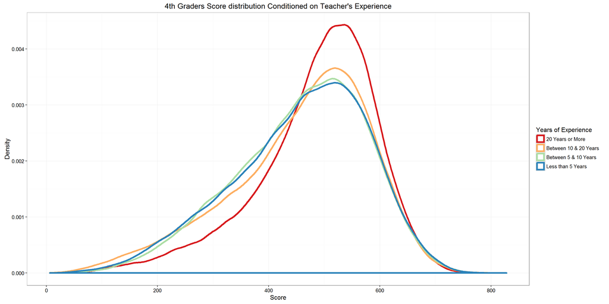

```r
#4Th graders, experience
ggplot(filter(ets,idpop==1),
           aes(x=score,color=factor(experience)))+geom_density(size=rel(1.5))+
  labs(x="Score",y="Density",title="4th Graders Score distribution Conditioned on Teacher's Experience")+
  scale_color_brewer(palette = "Spectral",
                     labels=c("20 Years or More","Between 10 & 20 Years","Between 5 & 10 Years","Less than 5 Years"),
                     name="Years of Experience")+
  theme_bw()
```

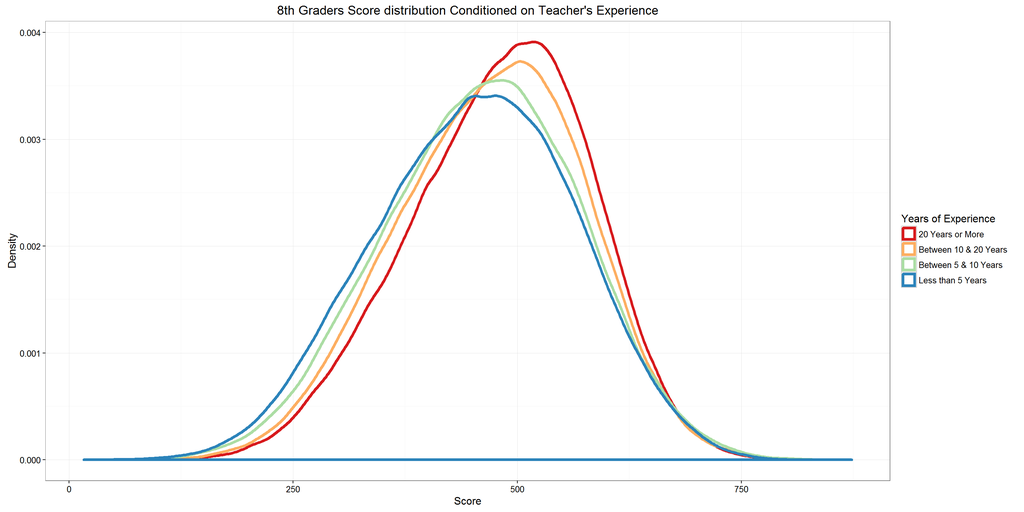

```r
#8Th graders, experience
ggplot(filter(ets,idpop==2),
           aes(x=score,color=factor(experience)))+geom_density(size=rel(1.5))+
  labs(x="Score",y="Density",title="8th Graders Score distribution Conditioned on Teacher's Experience")+
  scale_color_brewer(palette = "Spectral",
                     labels=c("20 Years or More","Between 10 & 20 Years","Between 5 & 10 Years","Less than 5 Years"),
                     name="Years of Experience")+
  theme_bw()
```

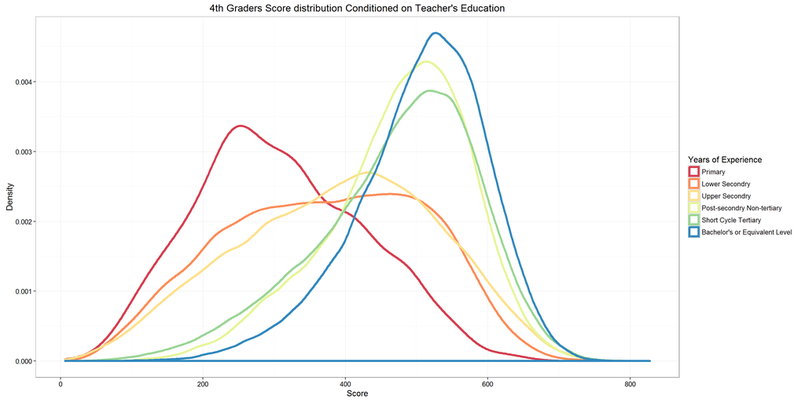

```r
#4Th graders, education
ggplot(filter(ets,idpop==1),
           aes(x=score,color=factor(education)))+geom_density(size=rel(1.5))+
  labs(x="Score",y="Density",title="4th Graders Score distribution Conditioned on Teacher's Education")+
  scale_color_brewer(palette = "Spectral",
                     labels=c("Primary","Lower Secondry","Upper Secondry","Post-secondry Non-tertiary",
                              "Short Cycle Tertiary","Bachelor's or Equivalent Level"),
                     name="Years of Experience")+
  theme_bw()
```

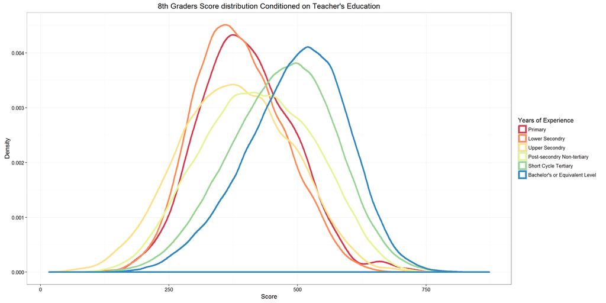

```r
#8Th graders, education
ggplot(filter(ets,idpop==2),
           aes(x=score,color=factor(education)))+geom_density(size=rel(1.5))+
  labs(x="Score",y="Density",title="8th Graders Score distribution Conditioned on Teacher's Education")+
  scale_color_brewer(palette = "Spectral",
                     labels=c("Primary","Lower Secondry","Upper Secondry","Post-secondry Non-tertiary",
                              "Short Cycle Tertiary","Bachelor's or Equivalent Level"),
                     name="Years of Experience")+
  theme_bw()
```

We certainly can notice some differences between the distributions. We’re going to findout if they mean anything.

### 4.3 Numeric Calculations:

We’ll calculate the quantiles of our samples to gain some sense over them.

```r
quantile(filter(ets,idpop==1,experience==1)$score)
```

```
##        0%       25%       50%       75%      100%
##  14.76019 430.45785 504.00022 561.24305 779.12826
```

```r
quantile(filter(ets,idpop==2,experience==1)$score)
```

```
##        0%       25%       50%       75%      100%
##  36.94856 412.12757 487.38806 552.73637 848.52450
```

```r
quantile(filter(ets,idpop==1,education==6)$score)
```

```
##        0%       25%       50%       75%      100%
##  39.41855 450.63157 515.74997 570.63911 769.95883
```

```r
quantile(filter(ets,idpop==2,education==6)$score)
```

```
##        0%       25%       50%       75%      100%
##  93.41196 433.06976 504.30380 566.97687 872.97117
```

```r
quantile(filter(ets,idpop==1,experience==4)$score)
```

```
##        0%       25%       50%       75%      100%
##  21.88446 377.96330 471.82017 546.84885 827.78143
```

```r
quantile(filter(ets,idpop==2,experience==4)$score)
```

```
##        0%       25%       50%       75%      100%
##  16.39331 374.26760 455.55638 531.54258 821.96526
```

```r
quantile(filter(ets,idpop==1,education==1)$score)
```

```
##        0%       25%       50%       75%      100%
##  14.76019 223.83995 297.24415 392.56647 661.94178
```

```r
quantile(filter(ets,idpop==2,education==1)$score)
```

```
##       0%      25%      50%      75%     100%
## 178.2116 339.0434 395.1857 464.8774 722.5341
```

### 4.4 Hypothesis Testing:

Similar to the 2 previous questions, the score variable is continues and according to the CLT, the sample mean has a normal distribution. Thus, we can take a t.test to find out if a difference in teachers education/experience causes a meaningful difference in the students average score.

```r
#4Th graders, experience
t.test(filter(ets,idpop==1,experience==1)$score,filter(ets,idpop==1,experience==4)$score)
```

```
##
##  Welch Two Sample t-test
##
## data:  filter(ets, idpop == 1, experience == 1)$score and filter(ets, idpop == 1, experience == 4)$score
## t = 50.069, df = 96597, p-value < 2.2e-16
## alternative hypothesis: true difference in means is not equal to 0
## 95 percent confidence interval:
##  28.82331 31.17186
## sample estimates:
## mean of x mean of y
##  486.4510  456.4534
```

```r
#8Th graders, experience
t.test(filter(ets,idpop==2,experience==1)$score,filter(ets,idpop==2,experience==4)$score)
```

```
##
##  Welch Two Sample t-test
##
## data:  filter(ets, idpop == 2, experience == 1)$score and filter(ets, idpop == 2, experience == 4)$score
## t = 74.328, df = 214700, p-value < 2.2e-16
## alternative hypothesis: true difference in means is not equal to 0
## 95 percent confidence interval:
##  27.52033 29.01102
## sample estimates:
## mean of x mean of y
##  480.0342  451.7686
```

```r
#4Th graders, education
t.test(filter(ets,idpop==1,education==6)$score,filter(ets,idpop==1,education==1)$score)
```

```
##
##  Welch Two Sample t-test
##
## data:  filter(ets, idpop == 1, education == 6)$score and filter(ets, idpop == 1, education == 1)$score
## t = 83.97, df = 2689, p-value < 2.2e-16
## alternative hypothesis: true difference in means is not equal to 0
## 95 percent confidence interval:
##  192.7520 201.9695
## sample estimates:
## mean of x mean of y
##  505.3135  307.9527
```

```r
#8Th graders, education
t.test(filter(ets,idpop==2,education==6)$score,filter(ets,idpop==2,education==1)$score)
```

```
##
##  Welch Two Sample t-test
##
## data:  filter(ets, idpop == 2, education == 6)$score and filter(ets, idpop == 2, education == 1)$score
## t = 35.559, df = 1169.9, p-value < 2.2e-16
## alternative hypothesis: true difference in means is not equal to 0
## 95 percent confidence interval:
##   89.83577 100.32832
## sample estimates:
## mean of x mean of y
##  496.9608  401.8788
```

### 4.5 Analyzing the results:

I have taken 4 distinct t-tests. between the 2 highest and lowest values of education/experience for 4th/8th graders separately. The results can be seen in the table below.

[output not shown]

Since all the p-values are quite small, we can conclude that the difference in the scores isn’t accidental. But let’s see what do these numbers mean. We can confidently state that there is a correlation between teachers experiance/education and the students success, but lets make more specific observation by comparing the Confidence intervals.

- Teachers Education is *Exteremly* important to 4th graders. It can cause a significant harm to student’s success. (3rd row)
- The effect of education on students success is *as real as* the experience, but much more influental. (comparing the Confidence intervals of first 2 rows with the last 2 rows)
- The Teachers experience and education, affects the 4th graders more than the 8th graders. i.e. the knowledge of the 4th graders depends more on their teachers than the 8th graders.

## 5. The Students from the schools with better utilities have better scores than others.

### 5.1 Data:

First we’ll group the *asg* data by school and grade(4/8) and calculate the average student score in each school in each grade. There are many variables in the *acg* and *bcg* datasets related to the schools utility. I’m going to use two of them that are explain below

- IDCNTRY : Country’s ID
- IDSCHOOL : School’s ID
- STUDID : Student’s ID
- ASMMAT01-ASMMAT05 : Student’s Overall Math Score Plausible Values
- ASSSCI01-ASSSCI05 : Student’s Overall Science Score Plausible Values
- ACDG09 : School Library Books
- ACDGCMP/BCDGCMP : Computer Available Per Student

Utility variables:

| Value | ACDG09 | ACDGCMP/BCDGMP |
| --- | --- | --- |
| 1 | Library with Above 5000 Books | 1 PC for 1-2 Student |
| 2 | Library with 500-5000 Books | 1 PC for 3-4 Students |
| 3 | Library with Below 500 Books | 1 Pc for 6 or More Students |
| 4 | No Library | No PCs Available |

```r
asg %>% mutate(ms=(asmmat01+asmmat02+asmmat03+asmmat04+asmmat05)/5,
               ss=(asssci01+asssci02+asssci03+asssci04+asssci05)/5) %>%
  mutate(as=(ms+ss)/2) %>%
  select(idcntry,idschool,as,idpop) %>%
  group_by(idpop,idschool,idcntry) %>%
  summarise(MAS=round(mean(as,na.rm=T),2))->sgs1

bsg %>% mutate(ms=(bsmmat01+bsmmat02+bsmmat03+bsmmat04+bsmmat05)/5,
               ss=(bsssci01+bsssci02+bsssci03+bsssci04+bsssci05)/5) %>%
  mutate(as=(ms+ss)/2) %>%
  select(idcntry,idschool,as,idpop) %>%
  group_by(idpop,idschool,idcntry) %>%
  summarise(MAS=round(mean(as,na.rm=T),2))->sgs2


acg %>% select(idcntry,idschool,lib=acdg09,cmp=acdgcmp)->sus1
bcg %>% select(idcntry,idschool,cmp=bcdgcmp)->sus2

sus1<-merge(sus1,sgs1,by=c("idcntry","idschool"))
sus1 %>% filter(!is.na(cmp),!is.na(lib))->sus1

sus2<-merge(sus2,sgs2,by=c("idcntry","idschool"))
sus2 %>% filter(!is.na(cmp))->sus2

remove(sgs1)
remove(sgs2)
```

### 5.2 Plotting:

The Distribution of Mean score at schools are compared below for different values of library and computer utilities. Note that the 8th graders data doesn’t contain the library column, thus the comparision is made over PCs only.

```r
#effect of Libs and Pcs on 4th graders Score
highchart() %>%
  hc_add_series_boxplot(sus1$MAS,by=sus1$lib,name="Libraries") %>%
  hc_add_series_boxplot(sus1$MAS,by=sus1$cmp,name="Computers") %>%
  hc_add_theme(hc_theme_smpl()) %>%
  hc_title(text = "effect of Libs and Pcs on 4th graders Score")
```

[interactive chart not shown]

```r
#effect of PCs on 8th Graders score
highchart() %>%
  hc_add_series_boxplot(sus2$MAS,by=sus2$cmp,name="Computers") %>%
  hc_add_theme(hc_theme_smpl()) %>%
  hc_title(text="effect of PCs on 8th Graders score")
```

[interactive chart not shown]

### 5.3 Numeric Calculations:

We’ll calculate the quantiles of our samples to gain some sense over them.

```r
quantile(filter(sus2,cmp==1)$MAS)
```

```
##     0%    25%    50%    75%   100%
## 204.80 432.41 488.94 532.07 735.79
```

```r
quantile(filter(sus2,cmp==1)$MAS)
```

```
##     0%    25%    50%    75%   100%
## 204.80 432.41 488.94 532.07 735.79
```

```r
quantile(filter(sus1,cmp==1)$MAS)
```

```
##       0%      25%      50%      75%     100%
## 130.5600 458.8350 512.0250 546.7075 758.4900
```

```r
quantile(filter(sus2,cmp==2)$MAS)
```

```
##     0%    25%    50%    75%   100%
## 199.44 427.15 480.85 530.73 744.61
```

```r
quantile(filter(sus2,cmp==4)$MAS)
```

```
##      0%     25%     50%     75%    100%
## 220.760 336.525 379.430 433.005 555.170
```

```r
quantile(filter(sus1,cmp==4)$MAS)
```

```
##     0%    25%    50%    75%   100%
##  78.57 311.55 407.14 473.62 650.85
```

```r
quantile(filter(sus1,lib==4)$MAS)
```

```
##     0%    25%    50%    75%   100%
##  78.57 321.56 430.48 522.69 656.71
```

```r
quantile(filter(sus1,lib==1)$MAS)
```

```
##       0%      25%      50%      75%     100%
## 231.6900 490.4625 528.0300 565.6000 758.4900
```

### 5.4 Hypothesis Testing:

```r
#Lib for 4th
t.test(filter(sus1,lib==1)$MAS,filter(sus1,lib==4)$MAS)
```

```
##
##  Welch Two Sample t-test
##
## data:  filter(sus1, lib == 1)$MAS and filter(sus1, lib == 4)$MAS
## t = 30.997, df = 1701.8, p-value < 2.2e-16
## alternative hypothesis: true difference in means is not equal to 0
## 95 percent confidence interval:
##   98.99581 112.37024
## sample estimates:
## mean of x mean of y
##  522.3684  416.6854
```

```r
#PC for 4th
t.test(filter(sus1,cmp==1)$MAS,filter(sus1,cmp==4)$MAS)
```

```
##
##  Welch Two Sample t-test
##
## data:  filter(sus1, cmp == 1)$MAS and filter(sus1, cmp == 4)$MAS
## t = 27.211, df = 1087, p-value < 2.2e-16
## alternative hypothesis: true difference in means is not equal to 0
## 95 percent confidence interval:
##   96.55782 111.56520
## sample estimates:
## mean of x mean of y
##  496.2568  392.1953
```

```r
#Pc for 8th
t.test(filter(sus2,cmp==1)$MAS,filter(sus2,cmp==4)$MAS)
```

```
##
##  Welch Two Sample t-test
##
## data:  filter(sus2, cmp == 1)$MAS and filter(sus2, cmp == 4)$MAS
## t = 28.148, df = 659.12, p-value < 2.2e-16
## alternative hypothesis: true difference in means is not equal to 0
## 95 percent confidence interval:
##   88.70608 102.01012
## sample estimates:
## mean of x mean of y
##  480.2614  384.9033
```

```r
#pc for 8th non extreme
t.test(filter(sus2,cmp==1)$MAS,filter(sus2,cmp==2)$MAS)
```

```
##
##  Welch Two Sample t-test
##
## data:  filter(sus2, cmp == 1)$MAS and filter(sus2, cmp == 2)$MAS
## t = 0.9709, df = 4777.7, p-value = 0.3316
## alternative hypothesis: true difference in means is not equal to 0
## 95 percent confidence interval:
##  -2.030939  6.016186
## sample estimates:
## mean of x mean of y
##  480.2614  478.2688
```

### 5.5 Analyzing the results:

In the table below, t.test values of each of the tests are listed:

[output not shown]

### First 3 Test:

It’s obvious that in each test $H_0$ is wrong. So, we can conclude that *Utilities is school can increase the student’s performance*. Also the following statements can be infered from the t.test results.

## 6. Having sufficient utilities at home has a positive effect in student’s educational progress.

### 6.1 Data:

To answer this question, I have made the following assumptions:

- An 8th grader, living in a good home, has lived in a good home since 4th grade.
- Even though we are comparing the scores of two different generation of the student’s, the average score of 4th graders, can be a good estimation for the average score of current 8th graders, when they were at 4th grade.

The Dataframe used in this part:

*asg/bsg : Student Background Data

The following variables are used:

- ASDG05S/BSDG05S : Number of home study supports
- IDPOP: Standardized Grade ID (4th or 8th)
- IDCNTRY : Student’s Country
- STUDID : Student’s ID
- ASMMAT01-ASMMAT05/BSMMAT01-BSMMAT05 : Student’s Overall Math Score Plausible Values
- ASSSCI01-ASSSCI05/BSSSCI01-BSSSCI05: Student’s Overall Science Score Plausible Values

Explanation of ASDG05S/BSDG05S:

```r
asg %>% mutate(ms=round((asmmat01+asmmat02+asmmat03+asmmat04+asmmat05)/5,2),
               ss=round((asssci01+asssci02+asssci03+asssci04+asssci05)/5,2)) %>%
  mutate(as=(ms+ss)/2) %>%
  select(idcntry,idstud,as,idpop,welfare=asdg05s)->asg6

bsg %>%  mutate(ms=round((bsmmat01+bsmmat02+bsmmat03+bsmmat04+bsmmat05)/5,2),
               ss=round((bsssci01+bsssci02+bsssci03+bsssci04+bsssci05)/5,2)) %>%
  mutate(as=(ms+ss)/2) %>%
  select(idcntry,idstud,as,idpop,welfare=bsdg05s)->bsg6

hws<-rbind(asg6,bsg6)

hws %>% filter(!is.na(welfare)) ->hws

remove(asg6)+remove(bsg6)
```

```
## numeric(0)
```

### 6.2 Plotting:

having the first two assumption in mind, we will compare the average scores of 4th graders and 8th graders for each level of household welfare. We can see that no matter what the welfare level is, the progress is negative, but the average score increases with welfare. with a t-test we’ll findout if this guess is true.

```r
highchart() %>%
  hc_add_series_boxplot(filter(hws,welfare==0)$as,filter(hws,welfare==0)$idpop,name="Low Welfare Level") %>%
  hc_add_series_boxplot(filter(hws,welfare==1)$as,filter(hws,welfare==1)$idpop,name="Mid Welfare Level") %>%
  hc_add_series_boxplot(filter(hws,welfare==2)$as,filter(hws,welfare==2)$idpop,name="High Welfare Level") %>%
  hc_title(text="Comparing Student's progress for different levels of welfare") %>%
  hc_add_theme(hc_theme_smpl())
```

[interactive chart not shown]

### 6.3 Numeric Calculations:

We’ll calculate the quantiles of our samples to gain some sense over them.

```r
quantile(filter(hws,welfare==2,idpop==2)$as)
```

```
##      0%     25%     50%     75%    100%
##  86.260 436.980 502.685 561.790 822.020
```

```r
quantile(filter(hws,welfare==1,idpop==2)$as)
```

```
##       0%      25%      50%      75%     100%
## 101.6600 372.3225 444.5250 516.7200 817.8850
```

```r
quantile(filter(hws,welfare==0,idpop==2)$as)
```

```
##       0%      25%      50%      75%     100%
##  64.2250 329.6637 392.7325 456.2150 754.3650
```

```r
quantile(filter(hws,welfare==2,idpop==1)$as)
```

```
##      0%     25%     50%     75%    100%
##  54.000 463.340 523.045 572.765 820.940
```

```r
quantile(filter(hws,welfare==1,idpop==1)$as)
```

```
##       0%      25%      50%      75%     100%
##  50.7600 408.9425 484.9650 547.9550 817.0950
```

```r
quantile(filter(hws,welfare==0,idpop==1)$as)
```

```
##       0%      25%      50%      75%     100%
##  25.4550 314.5825 408.3000 483.5250 776.4900
```

### 6.4 Hypothesis Testing:

Our goal is to findout whether having lived in a utilized household has a positive correlation with student’s progress. To investigate this, i’ll compare the scores of student’s in 4th & 8th grades with who have the same utilities at home. Now lets check If there is a meaningful positive difference between the average score in the houses with the highest utilities, compared to the poor.

```r
# NO UTILITIES - Low Level
t.test(x=filter(hws,welfare==0,idpop==2)$as,y=filter(hws,welfare==0,idpop==1)$as)
```

```
##
##  Welch Two Sample t-test
##
## data:  filter(hws, welfare == 0, idpop == 2)$as and filter(hws, welfare == 0, idpop == 1)$as
## t = -2.6227, df = 80819, p-value = 0.008725
## alternative hypothesis: true difference in means is not equal to 0
## 95 percent confidence interval:
##  -3.3562328 -0.4853435
## sample estimates:
## mean of x mean of y
##  393.6500  395.5708
```

```r
#EITHER INTERNET OR A ROOM - Mid Level
t.test(x=filter(hws,welfare==1,idpop==2)$as,y=filter(hws,welfare==1,idpop==1)$as)
```

```
##
##  Welch Two Sample t-test
##
## data:  filter(hws, welfare == 1, idpop == 2)$as and filter(hws, welfare == 1, idpop == 1)$as
## t = -57.414, df = 192640, p-value < 2.2e-16
## alternative hypothesis: true difference in means is not equal to 0
## 95 percent confidence interval:
##  -28.34591 -26.47447
## sample estimates:
## mean of x mean of y
##  445.2185  472.6287
```

```r
#BOTH INTERNET AND A ROOM - High Level
t.test(x=filter(hws,welfare==2,idpop==2)$as,y=filter(hws,welfare==2,idpop==1)$as)
```

```
##
##  Welch Two Sample t-test
##
## data:  filter(hws, welfare == 2, idpop == 2)$as and filter(hws, welfare == 2, idpop == 1)$as
## t = -40.38, df = 288210, p-value < 2.2e-16
## alternative hypothesis: true difference in means is not equal to 0
## 95 percent confidence interval:
##  -14.64843 -13.29226
## sample estimates:
## mean of x mean of y
##  496.7390  510.7093
```

### 6.5 Analyzing the results:

The results of the t-test are listed below:

| Category | P-value | 8th graders’ Score | 4th grader’s Score | Confidence Interval |
| --- | --- | --- | --- | --- |
| Low Level of Welfare | $0.008$ | $393.65$ | $395.57$ | $[-3.3 -0.5]$ |
| Mid Level of Welfare | $<2.2e-16$ | $445.22$ | $472.63$ | $[-28, -26]$ |
| High Level of Welfare | $<2.2e-16$ | $496.74$ | $510.70$ | $[-14, -13]$ |

comparing the confidence intervals and p values, we can derive the following statements:

- 1. In all of the tests, the p-value is small, thus $H_0$ is wrong.
- 2. No matter what the welfare level is, there is’nt a progress from 4th to 8th grade.
- 3. When the welfare level is low, the score drop is less significant than the other levels.
- 4. in general, the students with better household utilities have better grades (should be prooven with some other t-test) but the *progress* of the student’s has nothing to do with they’re home utilities.
- 5. these results can mean that our primary assumptions were wrong, but I couldn’t find any other better variable for estimating students progress.

## 7. Calm and steady environment at school plays an important role in student’s educational progress.

### 7.1 Data:

Since we dont have the 4th grade school and score data for the current 8th graders, we have to make the two following assumptions:

- An 8th grader current school’s level of order is the same as the 8th grader’s school back in 4th grade
- The current 4th grade data is a good estimation for the past of the current 8th graders

Dataframes:

*acg/bcg* asg/bsg

Variables:

- ACDGDAS/BCDGDAS : School Discipline and safety
- ACBG15E/BCBG17E : School Orderly Atmosphere
- IDPOP : Standardized Grade ID (4th or 8th)
- IDCNTRY : Student’s Country
- SCHOOLID :School’s ID
- ASMMAT01-ASMMAT05/BSMMAT01-BSMMAT05 : Student’s Overall Math Score Plausible Values
- ASSSCI01-ASSSCI05/BSSSCI01-BSSSCI05: Student’s Overall Science Score Plausible Values

Meaning of new variables:

| Value | (A/B)CDGDAS |
| --- | --- |
| 1 | Hardly any problems |
| 2 | Minor Problems |
| 3 | Moderate Problems |

```r
asg %>% mutate(ms=round((asmmat01+asmmat02+asmmat03+asmmat04+asmmat05)/5,2),
               ss=round((asssci01+asssci02+asssci03+asssci04+asssci05)/5,2)) %>%
  mutate(as=(ms+ss)/2) %>%
  select(idcntry,as,idpop,idschool)->asg7

bsg %>%  mutate(ms=round((bsmmat01+bsmmat02+bsmmat03+bsmmat04+bsmmat05)/5,2),
               ss=round((bsssci01+bsssci02+bsssci03+bsssci04+bsssci05)/5,2)) %>%
  mutate(as=(ms+ss)/2) %>%
  select(idcntry,as,idpop,idschool)->bsg7

sss <- rbind(merge(select(acg,disip=acdgdas,order=acbg15e,idcntry,idschool),asg7),
      merge(select(bcg,disip=bcdgdas,order=bcbg17e,idcntry,idschool),bsg7))

sss %>% filter(!is.na(order),!is.na(disip)) %>% group_by(idcntry,idschool,idpop) %>%
  summarise(order=mean(order,na.rm=T),disip=mean(disip,na.rm=T),MS=round(mean(as),2)) ->sss

remove(asg7)+remove(bsg7)
```

```
## numeric(0)
```

```r
knitr::kable(sss[1:10,])
```

| idcntry | idschool | idpop | order | disip | MS |
| --- | --- | --- | --- | --- | --- |
| 31 | 1 | 1 | 3 | 1 | 389.84 |
| 31 | 4 | 1 | 3 | 1 | 361.24 |
| 31 | 6 | 1 | 3 | 1 | 412.82 |
| 31 | 7 | 1 | 3 | 3 | 371.66 |
| 31 | 8 | 1 | 3 | 1 | 594.97 |
| 31 | 10 | 1 | 2 | 3 | 430.61 |
| 31 | 14 | 1 | 3 | 3 | 351.42 |
| 31 | 15 | 1 | 3 | 1 | 397.43 |
| 31 | 17 | 1 | 3 | 3 | 301.35 |
| 31 | 18 | 1 | 1 | 3 | 459.79 |

### 7.2 Plotting:

In this plot the changes in a single grade score distribution for different levels of order and calmness is ilustrated. The Xaxis show the grade number, 1 for 4th grade and 2 for 8th grade.

```r
highchart() %>%
  hc_add_series_boxplot(filter(sss,disip==1)$MS,filter(sss,disip==1)$idpop,name="Calm and Disciplined Schools") %>%
  hc_add_series_boxplot(filter(sss,disip==2)$MS,filter(sss,disip==2)$idpop,name="Average Schools") %>%
  hc_add_series_boxplot(filter(sss,disip==3)$MS,filter(sss,disip==3)$idpop,name="Chaotic Schools") %>%
  hc_add_theme(hc_theme_smpl()) %>%
  hc_title(text="Comparision of score distribution among various school environment ")
```

[interactive chart not shown]

In the next plot the changes in 4th and 8th grade for each type of school disciplinary is plotted. The Xaxis show the schools disciple, according to the *variable value explanation* in the data section above.

```r
highchart() %>%
  hc_add_series_boxplot(filter(sss,idpop==1)$MS,filter(sss,idpop==1)$disip,name="4th Grade") %>%
  hc_add_series_boxplot(filter(sss,idpop==2)$MS,filter(sss,idpop==2)$disip,name="8th Grade") %>%
  hc_add_theme(hc_theme_smpl()) %>%
  hc_title(text="Comparision of score distribution among students grade")
```

[interactive chart not shown]

### 7.3 Numeric Calculations:

We suspect that increasing environment’s level of order and discipline, increases the student’s progress. lets compare the average scores in both grades in different situations.

```r
sss %>% group_by(disip,idpop) %>% summarise(AS=round(mean(MS),2))->ssa
names(ssa)=c("Level Of Discipline & order","Student's Grade","Average score in math and science")
knitr::kable(ssa)
```

| Level Of Discipline & order | Student’s Grade | Average score in math and science |
| --- | --- | --- |
| 1 | 1 | 499.76 |
| 1 | 2 | 482.28 |
| 2 | 1 | 469.69 |
| 2 | 2 | 464.93 |
| 3 | 1 | 389.85 |
| 3 | 2 | 419.20 |

### 7.4 Hypothesis Testing:

Exactly Similar to the previous question, we’re comparing a series of school average scores which is a continues variable, obeying the CLT. Thus, by taking a t-test we can determine the relation between the 4th graders and 8th graders scores, studying in the same type of school, discipline wise.

```r
#highly disciplined
t.test(filter(sss,disip==1,idpop==2)$MS,filter(sss,disip==1,idpop==1)$MS)
```

```
##
##  Welch Two Sample t-test
##
## data:  filter(sss, disip == 1, idpop == 2)$MS and filter(sss, disip == 1, idpop == 1)$MS
## t = -10.206, df = 6301.8, p-value < 2.2e-16
## alternative hypothesis: true difference in means is not equal to 0
## 95 percent confidence interval:
##  -20.83794 -14.12251
## sample estimates:
## mean of x mean of y
##  482.2846  499.7648
```

```r
#average
t.test(filter(sss,disip==2,idpop==2)$MS,filter(sss,disip==2,idpop==1)$MS)
```

```
##
##  Welch Two Sample t-test
##
## data:  filter(sss, disip == 2, idpop == 2)$MS and filter(sss, disip == 2, idpop == 1)$MS
## t = -2.3028, df = 5857.1, p-value = 0.02133
## alternative hypothesis: true difference in means is not equal to 0
## 95 percent confidence interval:
##  -8.8113518 -0.7076925
## sample estimates:
## mean of x mean of y
##  464.9344  469.6939
```

```r
#chaotic
t.test(filter(sss,disip==3,idpop==2)$MS,filter(sss,disip==3,idpop==1)$MS)
```

```
##
##  Welch Two Sample t-test
##
## data:  filter(sss, disip == 3, idpop == 2)$MS and filter(sss, disip == 3, idpop == 1)$MS
## t = 8.3251, df = 2159.6, p-value < 2.2e-16
## alternative hypothesis: true difference in means is not equal to 0
## 95 percent confidence interval:
##  22.44168 36.27238
## sample estimates:
## mean of x mean of y
##  419.2031  389.8461
```

### 7.5 Analyzing the results:

The results are listed in the table below:

[output not shown]

Due to the small amount of p-value in all the categories, $H_0$ is wrong. So let’s try to interpret the results using the confidence intervals.

*1) The progress in student’s grade is negative in average highly calm and ordered schools.* 2) The progress in student’s grade is positive in chaotic and non-disciplined schools. *3) In the same grade however, the better disciplined schools have a higher score. (can be shown with another t-test)* 4) In general, we conclude that 4th graders scores are highly effected by their schools. But 8th graders are less effected by their environment. Thus, in chaotic schools students’ scores drops and causes this positive progress in this typical type of school. *5) There is a meaningful correlation between student’s progress and their schools discipline, but dispite the statement in the question, *they are not necessarily positivly correlated*, unless we interpret it as a sign of 4th graders being more fragile and delicate to school environment.